# Análisis narrativo del archivo Netflix_titles: datos, limpieza y modelos en Python

Este notebook usa el dataset de los titulos de series y peliculas de netflix, el cual contiene una rica variedad de datos para practicar un flujo completo de trabajo con datos:

```python
import pandas as pd
import numpy as np
import matplotlib.pyplot as plt
import statsmodels.api as sm
import statsmodels.formula.api as smf
from sklearn.model_selection import train_test_split
from sklearn.metrics import accuracy_score, confusion_matrix, classification_report

plt.rcParams["figure.figsize"] = (8, 5)
plt.rcParams["axes.grid"] = True
```

## 1. Carga de datos

Cada fila representa un título disponible en Netflix, ya sea una película o una serie de televisión. Las columnas más importantes son:

- `show_id`: identificador único del título.
- `type`: tipo de contenido (`Movie` o `TV Show`).
- `title`: nombre del título.
- `director`: director del contenido (puede contener valores faltantes).
- `cast`: elenco principal (puede contener varios actores separados por comas).
- `country`: país o países de producción.
- `date_added`: fecha en la que el título fue agregado al catálogo de Netflix.
- `release_year`: año de lanzamiento del título.
- `rating`: clasificación por edades (por ejemplo, `TV-MA`, `PG-13`, `TV-14`).
- `duration`: duración en minutos para películas o número de temporadas para series.
- `listed_in`: categorías o géneros a los que pertenece el título.
- `description`: breve sinopsis del contenido.

Usaremos un archivo CSV local ubicado en `data_sets/netflix_titles.csv`, que contiene información sobre películas y series disponibles en el catálogo de Netflix para realizar análisis exploratorios y obtener insights sobre el contenido de la plataforma.

```python
from pathlib import Path

REPO_ROOT = Path.cwd() if (Path.cwd() / "data_sets").exists() else Path.cwd().parent
DATA_PATH = REPO_ROOT / "data_sets" / "netflix_titles.csv"


if DATA_PATH.exists():
    df_original = pd.read_csv(DATA_PATH)

print("Filas y columnas originales:", df_original.shape)
df_original.head()
```

```
Filas y columnas originales: (8807, 12)
```

|  | show_id | type | title | director | cast | country | date_added | release_year | rating | duration | listed_in | description |
| --- | --- | --- | --- | --- | --- | --- | --- | --- | --- | --- | --- | --- |
| 0 | s1 | Movie | Dick Johnson Is Dead | Kirsten Johnson | NaN | United States | September 25, 2021 | 2020 | PG-13 | 90 min | Documentaries | As her father nears the end of his life, filmm... |
| 1 | s2 | TV Show | Blood & Water | NaN | Ama Qamata, Khosi Ngema, Gail Mabalane, Thaban... | South Africa | September 24, 2021 | 2021 | TV-MA | 2 Seasons | International TV Shows, TV Dramas, TV Mysteries | After crossing paths at a party, a Cape Town t... |
| 2 | s3 | TV Show | Ganglands | Julien Leclercq | Sami Bouajila, Tracy Gotoas, Samuel Jouy, Nabi... | NaN | September 24, 2021 | 2021 | TV-MA | 1 Season | Crime TV Shows, International TV Shows, TV Act... | To protect his family from a powerful drug lor... |
| 3 | s4 | TV Show | Jailbirds New Orleans | NaN | NaN | NaN | September 24, 2021 | 2021 | TV-MA | 1 Season | Docuseries, Reality TV | Feuds, flirtations and toilet talk go down amo... |
| 4 | s5 | TV Show | Kota Factory | NaN | Mayur More, Jitendra Kumar, Ranjan Raj, Alam K... | India | September 24, 2021 | 2021 | TV-MA | 2 Seasons | International TV Shows, Romantic TV Shows, TV ... | In a city of coaching centers known to train I... |

## 2. Revisión inicial de los datos

Antes de limpiar, siempre conviene responder tres preguntas básicas:

1. ¿Qué columnas tengo?
2. ¿Qué tipo de dato tiene cada una?
3. ¿Hay valores faltantes o algo que no cuadre?

```python
print("Columnas disponibles:")
print(df_original.columns.tolist())

print("\nTipos de datos:")
display(df_original.dtypes.to_frame("tipo"))

print("\nValores faltantes por columna:")
missing = df_original.isnull().sum().sort_values(ascending=False)
missing_pct = (missing / len(df_original) * 100).round(1)
display(pd.DataFrame({"faltantes": missing, "porcentaje": missing_pct}))

print("\nCuantos son Movies y cuantos son Tv Shows:")
conteo = df_original["type"].value_counts()
display(conteo)
```

```
Columnas disponibles:
['show_id', 'type', 'title', 'director', 'cast', 'country', 'date_added', 'release_year', 'rating', 'duration', 'listed_in', 'description']

Tipos de datos:
```

|  | tipo |
| --- | --- |
| show_id | str |
| type | str |
| title | str |
| director | str |
| cast | str |
| country | str |
| date_added | str |
| release_year | int64 |
| rating | str |
| duration | str |
| listed_in | str |
| description | str |

```
Valores faltantes por columna:
```

|  | faltantes | porcentaje |
| --- | --- | --- |
| director | 2634 | 29.9 |
| country | 831 | 9.4 |
| cast | 825 | 9.4 |
| date_added | 10 | 0.1 |
| rating | 4 | 0.0 |
| duration | 3 | 0.0 |
| show_id | 0 | 0.0 |
| type | 0 | 0.0 |
| title | 0 | 0.0 |
| release_year | 0 | 0.0 |
| listed_in | 0 | 0.0 |
| description | 0 | 0.0 |

```
Cuantos son Movies y cuantos son Tv Shows:
```

```
type
Movie      6131
TV Show    2676
Name: count, dtype: int64
```

## 3. Auditoría de calidad

Esta auditoría nos dice *qué* hay que corregir y *por qué*.

```python
print("--- Auditoría de calidad ---")

# Filas duplicadas
duplicados = df_original.duplicated().sum()
print("Filas duplicadas:", duplicados)

# Valores nulos
print("\nValores nulos por columna:")
display(df_original.isnull().sum())

# Tipos de contenido inválidos
print("\nTipos de contenido inválidos:")
print((~df_original["type"].isin(["Movie", "TV Show"])).sum())

# Años de lanzamiento inválidos
print("\nAños de lanzamiento inválidos:")
print(((df_original["release_year"] < 1900) | (df_original["release_year"] > 2025)).sum())

# Identificadores duplicados
print("\nShow ID duplicados:")
print(df_original["show_id"].duplicated().sum())

# Valores únicos por columna
print("\nValores únicos por columna:")
for col in df_original.columns:
    print(f"- {col}: {df_original[col].nunique()}")

# Distribución del tipo de contenido
print("\nDistribución del tipo de contenido:")
display(df_original["type"].value_counts())

# Distribución de la clasificación por edades
print("\nDistribución de la clasificación (rating):")
display(df_original["rating"].value_counts(dropna=False))
```

```
--- Auditoría de calidad ---
Filas duplicadas: 0

Valores nulos por columna:
```

```
show_id            0
type               0
title              0
director        2634
cast             825
country          831
date_added        10
release_year       0
rating             4
duration           3
listed_in          0
description        0
dtype: int64
```

```
Tipos de contenido inválidos:
0

Años de lanzamiento inválidos:
0

Show ID duplicados:
0

Valores únicos por columna:
- show_id: 8807
- type: 2
- title: 8807
- director: 4528
- cast: 7692
- country: 748
- date_added: 1767
- release_year: 74
- rating: 17
- duration: 220
- listed_in: 514
- description: 8775

Distribución del tipo de contenido:
```

```
type
Movie      6131
TV Show    2676
Name: count, dtype: int64
```

```
Distribución de la clasificación (rating):
```

```
rating
TV-MA       3207
TV-14       2160
TV-PG        863
R            799
PG-13        490
TV-Y7        334
TV-Y         307
PG           287
TV-G         220
NR            80
G             41
TV-Y7-FV       6
NaN            4
NC-17          3
UR             3
74 min         1
84 min         1
66 min         1
Name: count, dtype: int64
```

## 4. Limpieza de datos

Vamos a limpiar el conjunto de datos paso a paso y documentar cada decisión tomada.

### Decisiones de limpieza

1. **`director`**: contiene una cantidad considerable de valores faltantes. En lugar de eliminarlos o inventar información, los reemplazamos por `"Desconocido"` para conservar los registros.
2. **`cast`**: algunos títulos no tienen elenco registrado. Sustituimos los valores nulos por `"No especificado"` para facilitar el análisis.
3. **`country`**: existen títulos sin país de producción. Reemplazamos los valores faltantes por `"Desconocido"` para mantener la consistencia del conjunto de datos.
4. **`date_added`**: algunos registros no cuentan con la fecha en que fueron agregados a Netflix. Conservamos estos valores nulos, ya que no es posible inferir la fecha con confianza.
5. **`release_year`**: verificamos que los años de lanzamiento se encuentren dentro de un rango razonable y que no existan valores anómalos, en caso de ser asi se sustituira con un "-1"
6. **Tipos de datos**: convertimos las columnas categóricas (`type`, `rating` y `listed_in`, entre otras) al tipo `category` para reducir el consumo de memoria y facilitar el análisis.

```python
print("--- Iniciando limpieza de datos ---")

df = df_original.copy()
filas_inicio = len(df)

# 1) director: reemplazar nulos con "Desconocido".
df["director"] = df["director"].fillna("Desconocido")

# 2) cast: reemplazar nulos con "No especificado".
df["cast"] = df["cast"].fillna("No especificado")

# 3) country: reemplazar nulos con "Desconocido".
df["country"] = df["country"].fillna("Desconocido")

# 4) date_added: mantenemos date.

# 5) release_year: verificamos que el año de lanzamiento este en un rango razonable, como es int al no estarlo colocaremos un valor como -1 ára indicar que la fecha es icorrecta
anio_actual = pd.Timestamp.now().year

df["release_year"] = df["release_year"].where(
    (df["release_year"] >= 1900) & (df["release_year"] <= anio_actual),
    -1
)
# 6) Tipos categoricos
df["type"] = df["type"].astype("category")
df["rating"] = df["rating"].astype("category")
df["listed_in"] = df["listed_in"].astype("category")


print(f"Filas al inicio: {filas_inicio}")
print(f"Filas después de limpieza: {len(df)}")
print(f"Filas eliminadas: {filas_inicio - len(df)}")

print("\nValores faltantes después de limpiar:")
display(df.isnull().sum().to_frame("faltantes"))

df.head()
```

```
--- Iniciando limpieza de datos ---
Filas al inicio: 8807
Filas después de limpieza: 8807
Filas eliminadas: 0

Valores faltantes después de limpiar:
```

|  | faltantes |
| --- | --- |
| show_id | 0 |
| type | 0 |
| title | 0 |
| director | 0 |
| cast | 0 |
| country | 0 |
| date_added | 10 |
| release_year | 0 |
| rating | 4 |
| duration | 3 |
| listed_in | 0 |
| description | 0 |

|  | show_id | type | title | director | cast | country | date_added | release_year | rating | duration | listed_in | description |
| --- | --- | --- | --- | --- | --- | --- | --- | --- | --- | --- | --- | --- |
| 0 | s1 | Movie | Dick Johnson Is Dead | Kirsten Johnson | No especificado | United States | September 25, 2021 | 2020 | PG-13 | 90 min | Documentaries | As her father nears the end of his life, filmm... |
| 1 | s2 | TV Show | Blood & Water | Desconocido | Ama Qamata, Khosi Ngema, Gail Mabalane, Thaban... | South Africa | September 24, 2021 | 2021 | TV-MA | 2 Seasons | International TV Shows, TV Dramas, TV Mysteries | After crossing paths at a party, a Cape Town t... |
| 2 | s3 | TV Show | Ganglands | Julien Leclercq | Sami Bouajila, Tracy Gotoas, Samuel Jouy, Nabi... | Desconocido | September 24, 2021 | 2021 | TV-MA | 1 Season | Crime TV Shows, International TV Shows, TV Act... | To protect his family from a powerful drug lor... |
| 3 | s4 | TV Show | Jailbirds New Orleans | Desconocido | No especificado | Desconocido | September 24, 2021 | 2021 | TV-MA | 1 Season | Docuseries, Reality TV | Feuds, flirtations and toilet talk go down amo... |
| 4 | s5 | TV Show | Kota Factory | Desconocido | Mayur More, Jitendra Kumar, Ranjan Raj, Alam K... | India | September 24, 2021 | 2021 | TV-MA | 2 Seasons | International TV Shows, Romantic TV Shows, TV ... | In a city of coaching centers known to train I... |

## 5. Creación de variables nuevas

Muchas veces la información más útil no se encuentra en una sola columna. Es necesario crear nuevas variables a partir de los datos existentes para facilitar el análisis.

Crearemos:

- `content_age`: antigüedad del título (`año_actual - release_year`).
- `is_movie`: 1 si el contenido es una película, 0 si es una serie de televisión.
- `duration_value`: duración numérica extraída de la columna `duration` (minutos para películas o temporadas para series).
- `duration_unit`: unidad de duración (`min` o `Season(s)`).
- `decade`: década de lanzamiento del título (1980s, 1990s, 2000s, 2010s, etc.).
- `genres_count`: cantidad de géneros asociados a cada título, obtenida a partir de la columna `listed_in`.
- `cast_size`: número de actores registrados en la columna `cast`.

Estas variables permiten responder preguntas como:

- ¿Qué décadas concentran la mayor cantidad de títulos disponibles?
- ¿Los títulos más recientes predominan en el catálogo de Netflix?
- ¿Qué tan frecuente es que un título pertenezca a varios géneros?

```python
# 1. is_movie: 1 si el contenido es una película, 0 si es una serie de televisión.
df["is_movie"] = (df["type"] == "Movie").astype(int)

# 2. content_age: antigüedad del título (año_actual - release_year).

anio_actual = pd.Timestamp.now().year
df["content_age"] = anio_actual - df["release_year"]

# 3. duration_value: duración numérica extraída de la columna duration (minutos para películas o temporadas para series).
df["duration_value"] = df["duration"].str.extract(r"(\d+)")


# 4. duration_unit: unidad de duración (min o Season(s)).
df["duration_unit"] = df["duration"].str.extract(r"([A-Za-z ]+)$")

#5. decade: década de lanzamiento del título (1980s, 1990s, 2000s, 2010s, etc.).
df["decade"] = (df["release_year"] // 10) * 10

#6. genres_count: cantidad de géneros asociados a cada título, obtenida a partir de la columna listed_in.
#df["genres_count"] = df["listed_in"].str.split(r",\s*").str.len()

df["genres_count"] = (
    df["listed_in"]
    .str.replace("&", ",", regex=False)
    .str.split(r",\s*")
    .str.len()
)

#7. cast_size: número de actores registrados en la columna cast.
df["cast_size"] = df["cast"].fillna("").str.split(r",\s*").str.len()
#Resultado:
new_columns = [
    "title","type","is_movie","release_year","content_age","duration",
    "duration_value","duration_unit","decade","genres_count","cast_size"
]

display(df[new_columns].head())

print("\nResumen de variables nuevas:")
display(df[new_columns].describe(include="all").T)
```

|  | title | type | is_movie | release_year | content_age | duration | duration_value | duration_unit | decade | genres_count | cast_size |
| --- | --- | --- | --- | --- | --- | --- | --- | --- | --- | --- | --- |
| 0 | Dick Johnson Is Dead | Movie | 1 | 2020 | 6 | 90 min | 90 | min | 2020 | 1 | 1 |
| 1 | Blood & Water | TV Show | 0 | 2021 | 5 | 2 Seasons | 2 | Seasons | 2020 | 3 | 19 |
| 2 | Ganglands | TV Show | 0 | 2021 | 5 | 1 Season | 1 | Season | 2020 | 4 | 9 |
| 3 | Jailbirds New Orleans | TV Show | 0 | 2021 | 5 | 1 Season | 1 | Season | 2020 | 2 | 1 |
| 4 | Kota Factory | TV Show | 0 | 2021 | 5 | 2 Seasons | 2 | Seasons | 2020 | 3 | 8 |

```
Resumen de variables nuevas:
```

|  | count | unique | top | freq | mean | std | min | 25% | 50% | 75% | max |
| --- | --- | --- | --- | --- | --- | --- | --- | --- | --- | --- | --- |
| title | 8807 | 8807 | Dick Johnson Is Dead | 1 | NaN | NaN | NaN | NaN | NaN | NaN | NaN |
| type | 8807 | 2 | Movie | 6131 | NaN | NaN | NaN | NaN | NaN | NaN | NaN |
| is_movie | 8807.0 | NaN | NaN | NaN | 0.696151 | 0.459944 | 0.0 | 0.0 | 1.0 | 1.0 | 1.0 |
| release_year | 8807.0 | NaN | NaN | NaN | 2014.180198 | 8.819312 | 1925.0 | 2013.0 | 2017.0 | 2019.0 | 2021.0 |
| content_age | 8807.0 | NaN | NaN | NaN | 11.819802 | 8.819312 | 5.0 | 7.0 | 9.0 | 13.0 | 101.0 |
| duration | 8804 | 220 | 1 Season | 1793 | NaN | NaN | NaN | NaN | NaN | NaN | NaN |
| duration_value | 8804 | 210 | 1 | 1793 | NaN | NaN | NaN | NaN | NaN | NaN | NaN |
| duration_unit | 8804 | 3 | min | 6128 | NaN | NaN | NaN | NaN | NaN | NaN | NaN |
| decade | 8807.0 | NaN | NaN | NaN | 2009.108664 | 9.228119 | 1920.0 | 2010.0 | 2010.0 | 2010.0 | 2020.0 |
| genres_count | 8807.0 | NaN | NaN | NaN | 2.490519 | 0.995274 | 1.0 | 2.0 | 3.0 | 3.0 | 6.0 |
| cast_size | 8807.0 | NaN | NaN | NaN | 7.374929 | 4.72885 | 1.0 | 4.0 | 8.0 | 10.0 | 50.0 |

```python
print("\n1. ¿Qué décadas concentran la mayor cantidad de títulos disponibles?:")
df["decade"].value_counts().sort_values(ascending=False)
```

```
1. ¿Qué décadas concentran la mayor cantidad de títulos disponibles?:
```

```
decade
2010    5927
2020    1545
2000     810
1990     274
1980     129
1970      70
1960      25
1940      15
1950      11
1920       1
Name: count, dtype: int64
```

```python
print("\n2. ¿Los títulos más recientes predominan en el catálogo de Netflix? (Peliculas de la ultima decada)")
decada_actual = df["decade"].max()

#Obtenemos solo los correspondientes a la decada actual
recientes = df[df["decade"] == decada_actual]

#Calculamos porcentaje:
porcentaje = len(recientes) / len(df) * 100

print(f"Títulos de la década más reciente ({decada_actual}s): {porcentaje:.2f}%")

if porcentaje > 50:
    print("Predominan")
else:
    print("No predomina")
```

```
2. ¿Los títulos más recientes predominan en el catálogo de Netflix? (Peliculas de la ultima decada)
Títulos de la década más reciente (2020s): 17.54%
No predomina
```

```python
print("\n3. ¿Qué tan frecuente es que un título pertenezca a varios géneros?:")
df["genres_count"].value_counts().sort_values(ascending=False)
```

```
3. ¿Qué tan frecuente es que un título pertenezca a varios géneros?:
```

```
genres_count
3    3353
2    2575
1    1659
4    1044
5     166
6      10
Name: count, dtype: int64
```

## 6. Visualizaciones exploratorias (Netflix)

Las tablas resumen números, pero las gráficas permiten identificar patrones en el catálogo de Netflix de forma más clara.

En este análisis exploratorio nos enfocamos en observar:

- La distribución entre películas y series de TV en el catálogo.
- Qué países concentran la mayor cantidad de contenido disponible.
- Cuáles son los géneros más frecuentes dentro de Netflix.
- Cómo se distribuyen los títulos a lo largo de los años y décadas de lanzamiento.
- Qué clasificaciones por edad (rating) predominan en la plataforma.

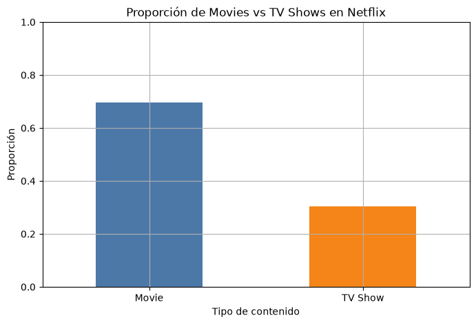

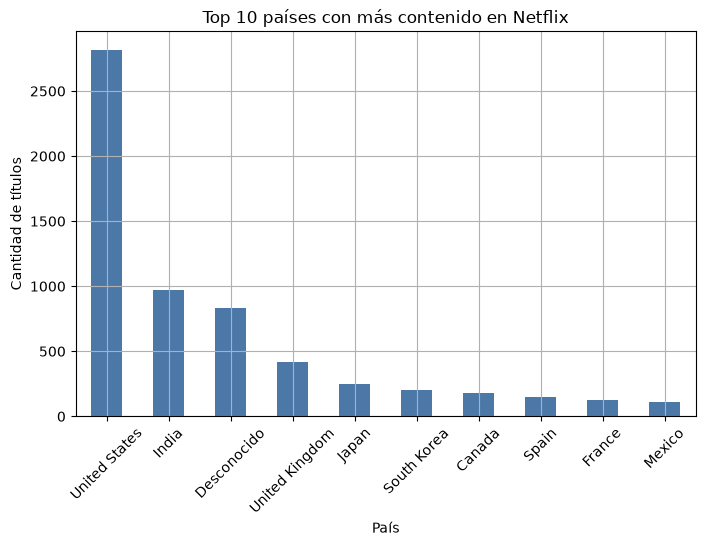

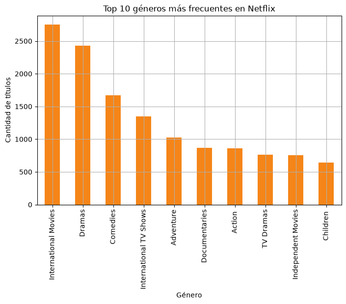

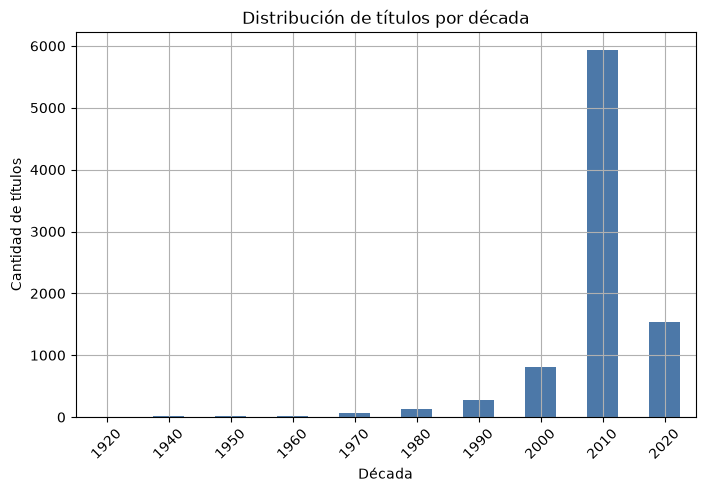

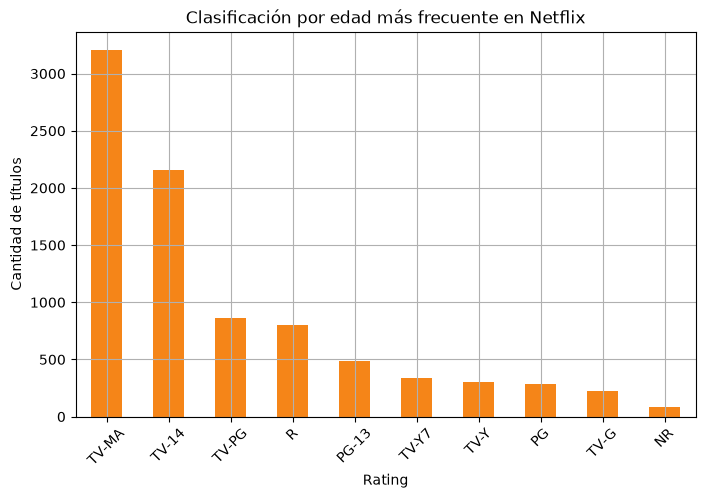

```python
content_type = df["type"].value_counts(normalize=True)

content_type.plot(
    kind="bar",
    color=["#4C78A8", "#F58518"],
    title="Proporción de Movies vs TV Shows en Netflix"
)

plt.ylabel("Proporción")
plt.xlabel("Tipo de contenido")
plt.xticks(rotation=0)
plt.ylim(0, 1)
plt.show()

top_countries = df["country"].value_counts().head(10)

top_countries.plot(
    kind="bar",
    color="#4C78A8",
    title="Top 10 países con más contenido en Netflix"
)

plt.ylabel("Cantidad de títulos")
plt.xlabel("País")
plt.xticks(rotation=45)
plt.show()

df_genres = (
    df["listed_in"]
    .str.replace("&", ",", regex=False)
    .str.split(r",\s*")
    .explode()
)

genres = df_genres.value_counts().head(10)

genres.plot(
    kind="bar",
    color="#F58518",
    title="Top 10 géneros más frecuentes en Netflix"
)

plt.ylabel("Cantidad de títulos")
plt.xlabel("Género")
plt.show()

decades = df["decade"].value_counts().sort_index()

decades.plot(
    kind="bar",
    color="#4C78A8",
    title="Distribución de títulos por década"
)

plt.ylabel("Cantidad de títulos")
plt.xlabel("Década")
plt.xticks(rotation=45)
plt.show()

ratings = df["rating"].value_counts().head(10)

ratings.plot(
    kind="bar",
    color="#F58518",
    title="Clasificación por edad más frecuente en Netflix"
)

plt.ylabel("Cantidad de títulos")
plt.xlabel("Rating")
plt.xticks(rotation=45)
plt.show()
```